# NumPy Operations

## Agenda

In this lab we are going to learn:-

1. Array Flatten,Transpose
2. Concatenating Arrays
3. Arithmatic Operations
4. Comparison Operators
5. Array Sorting

## Flatten()

The `flatten()` function is used to get a copy of an given array collapsed into one dimension.

```python
import numpy as np

x = np.array([[1, 2, 3], [4, 5, 6]])
x
```

```
array([[1, 2, 3],
       [4, 5, 6]])
```

```python
x.flatten()
```

```
array([1, 2, 3, 4, 5, 6])
```

```python
y = np.array([[2,3], [4,5]])
y
```

```
array([[2, 3],
       [4, 5]])
```

```python
y.flatten()
```

```
array([2, 3, 4, 5])
```

### Find the transpose of a array

```python
import numpy as np
a = np.array([[2.,3.],[4.,5.]])
print(a)
```

```
[[2. 3.]
 [4. 5.]]
```

```python
print(a.T)
```

```
[[2. 4.]
 [3. 5.]]
```

```python
arr =  np.random.randint(0,25,(3,3))
arr
```

```
array([[24, 20, 21],
       [ 8, 19, 21],
       [18,  8, 17]])
```

```python
arr.shape
```

```
(3, 3)
```

```python
arr.T
```

```
array([[24,  8, 18],
       [20, 19,  8],
       [21, 21, 17]])
```

### Numpy Array Concatenate

```python
import numpy as np

a = np.array([1, 2, 3])
print(a)
print(a.shape)

b = np.array([4, 5, 6])
print(b)
print(b.shape)
```

```
[1 2 3]
(3,)
[4 5 6]
(3,)
```

```python
print(np.concatenate((a,b)))
```

```
[1 2 3 4 5 6]
```

```python
c  =  np.concatenate((a,b))
c
```

```
array([1, 2, 3, 4, 5, 6])
```

```python
c.shape
```

```
(6,)
```

```python
c1 = np.concatenate((a,b),axis = 0)
c1
```

```
array([1, 2, 3, 4, 5, 6])
```

```python
import numpy as np
a = np.array([1, 2, 3])
print(a)

b = np.array([4, 5, 6])
print(b)

c = np.array([7, 8, 9])
print(c)

d = np.array([10, 11, 12])
print(d)
```

```
[1 2 3]
[4 5 6]
[7 8 9]
[10 11 12]
```

```python
#concatenate a,b,c,d
e = np.concatenate((a,b,c,d))
```

```python
e.shape
```

```
(12,)
```

```python
e
```

```
array([ 1,  2,  3,  4,  5,  6,  7,  8,  9, 10, 11, 12])
```

```python
x = np.array([[0, 1, 3], [5, 7, 9]])
y = np.array([[0, 2, 4], [6, 8, 10]])
```

```python
print(x)
```

```
[[0 1 3]
 [5 7 9]]
```

```python
x.shape
```

```
(2, 3)
```

```python
y.shape
```

```
(2, 3)
```

```python
print(y)
```

```
[[ 0  2  4]
 [ 6  8 10]]
```

```python
z = np.concatenate((x,y), axis = 0)   #try axis = 1
z
```

```
array([[ 0,  1,  3],
       [ 5,  7,  9],
       [ 0,  2,  4],
       [ 6,  8, 10]])
```

```python
z.shape
```

```
(4, 3)
```

## Arithmetic Operations

You can easily perform array with array arithmetic, or scalar with array arithmetic. Let's see some examples:

```python
data = np.array([1, 2])
ones = np.ones(2)
data + ones
```

```
array([2., 3.])
```

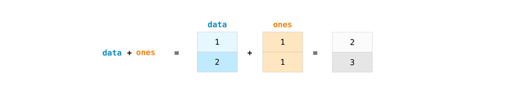

```python
data - ones
```

```
array([0., 1.])
```

```python
data * data
```

```
array([1, 4])
```

```python
data / data
```

```
array([1., 1.])
```

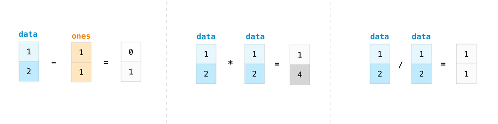

```python
data**4
```

```
array([ 1, 16])
```

## Broadcasting

There are times when you might want to carry out an operation between an array and a single number (also called an operation between a vector and a scalar) or between arrays of two different sizes. For example, your array (we’ll call it “data”) might contain information about distance in miles but you want to convert the information to kilometers. You can perform this operation with:

```python
data = np.array([1.0, 2.0])
data * 1.6
```

```
array([1.6, 3.2])
```

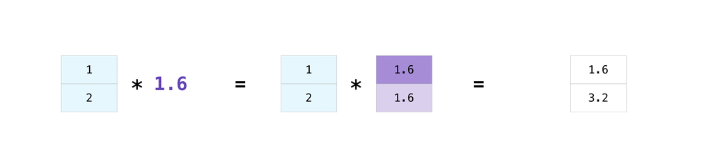

```python
data = np.array([[1, 2], [3, 4], [5, 6]])
ones_row = np.array([[1, 1]])
data + ones_row
```

```
array([[2, 3],
       [4, 5],
       [6, 7]])
```

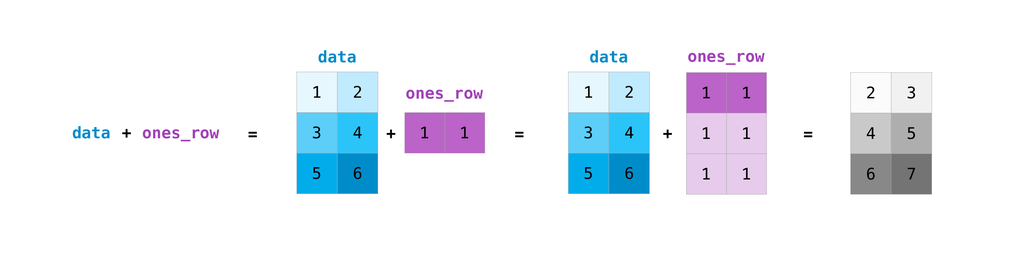

NumPy understands that the multiplication should happen with each cell. That concept is called **broadcasting**.

```python
np.arange(3)
```

```
array([0, 1, 2])
```

```python
np.arange(3) + 5
```

```
array([5, 6, 7])
```

```python
a = np.ones((3,3))
print(a)
print("\n shape:",a.shape)
```

```
[[1. 1. 1.]
 [1. 1. 1.]
 [1. 1. 1.]]

 shape: (3, 3)
```

```python
b = np.arange(3)
print(b)
print("\n shape:",b.shape)
```

```
[0 1 2]

 shape: (3,)
```

```python
a + b
```

```
array([[1., 2., 3.],
       [1., 2., 3.],
       [1., 2., 3.]])
```

```python
p = np.arange(3).reshape((3,1))
print(p)
print("\n shape:",p.shape)
```

```
[[0]
 [1]
 [2]]

 shape: (3, 1)
```

```python
q = np.arange(3)
print(q)
print("\n shape:",q.shape)
```

```
[0 1 2]

 shape: (3,)
```

```python
p + q
```

```
array([[0, 1, 2],
       [1, 2, 3],
       [2, 3, 4]])
```

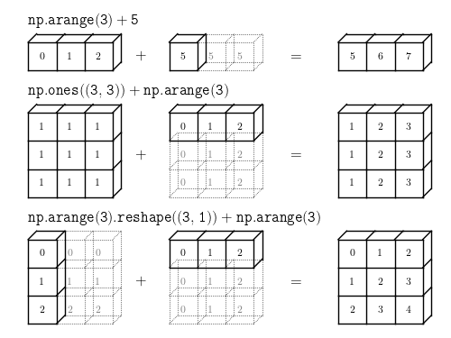

### More useful array operations

```python
data = np.arange(1,4)
data
```

```
array([1, 2, 3])
```

```python
data.max()
```

```
3
```

```python
data.min()
```

```
1
```

```python
data.sum()
```

```
6
```

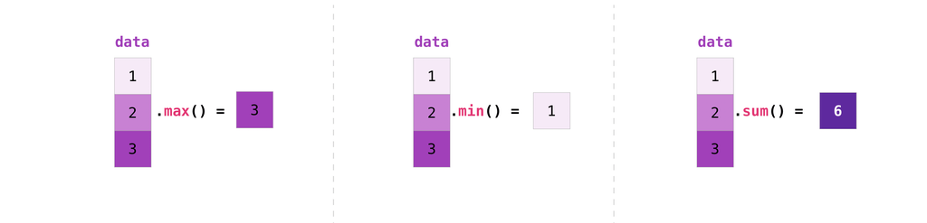

```python
data = np.array([[1, 2], [3, 4], [5,6]])
data
```

```
array([[1, 2],
       [3, 4],
       [5, 6]])
```

```python
data.max()
```

```
6
```

```python
data.min()
```

```
1
```

```python
data.sum()
```

```
21
```

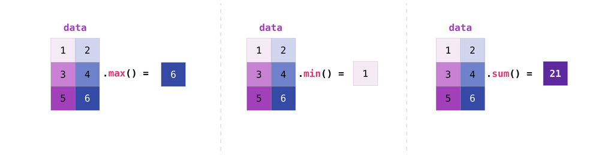

```python
data.max(axis=0)
```

```
array([5, 6])
```

```python
data.max(axis=1)
```

```
array([2, 4, 6])
```

[figure not shown]

**Remember that axis 0 is the axis that points downwards, down the rows.**

When we use the code `np.max(axis = 0)` on an array, we’re effectively telling NumPy to compute the maximum values in that direction … the axis 0 direction.

Similarly, remember that in a 2-dimensional array, axis 1 points horizontally. Therefore, when we use NumPy max with axis = 1, we’re telling NumPy to compute the maxima horizontally, in the axis 1 direction.

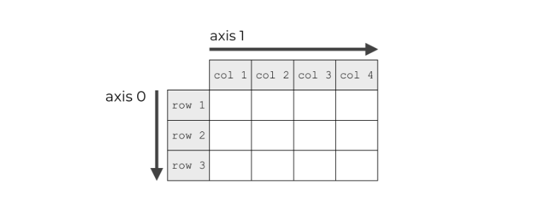

## Universal Array Functions

Numpy comes with many universal array functions, which are essentially just mathematical operations you can use to perform the operation across the array. Let's show some common ones:

```python
import numpy as np

data = np.array([[1, 2, 3], [4, 5, 6]])
print(data)
```

```
[[1 2 3]
 [4 5 6]]
```

```python
#Taking square
np.square(data)
```

```
array([[ 1,  4,  9],
       [16, 25, 36]])
```

```python
#Taking Square Roots
np.sqrt(data)
```

```
array([[1.        , 1.41421356, 1.73205081],
       [2.        , 2.23606798, 2.44948974]])
```

```python
#Calcualting exponential (e^)
np.exp(data)
```

```
array([[  2.71828183,   7.3890561 ,  20.08553692],
       [ 54.59815003, 148.4131591 , 403.42879349]])
```

### Comparison Operations

```python
x = np.array([1, 2, 3, 4, 5])
x
```

```
array([1, 2, 3, 4, 5])
```

```python
x < 3 # less than
```

```
array([ True,  True, False, False, False])
```

```python
x > 3 # greater than
```

```
array([False, False, False,  True,  True])
```

```python
x <= 3 # less than or equal to
```

```
array([ True,  True,  True, False, False])
```

```python
x >= 3 # greater than or equal to
```

```
array([False, False,  True,  True,  True])
```

```python
x != 3 # not equal
```

```
array([ True,  True, False,  True,  True])
```

```python
x == 3 # equal
```

```
array([False, False,  True, False, False])
```

### Sorting

```python
x = np.array([2, 1, 4, 3, 5])
print(x)
```

```
[2 1 4 3 5]
```

```python
np.sort(x)
```

```
array([1, 2, 3, 4, 5])
```

```python
y = np.array([10,20,1,3,45,76])
np.sort(y)
```

```
array([ 1,  3, 10, 20, 45, 76])
```

```python
np.unique([0,1,2,0,2,3,4,3,0,4,11, 12, 13,13,13,11])
```

```
array([ 0,  1,  2,  3,  4, 11, 12, 13])
```

# Great Job!

That's all we need to know for now!